# 每週一圖20191113

#### 環境設定

以下為老師執行時一定會存在的環境設定

```r
rm(list=ls())
library(dplyr); library(stringr); library(ggplot2); library(plotly); library(lubridate); library(readr); library(colorspace); library(grDevices); library(shiny); library(shinyjs); library(scales)
library(tidyr); library(showtext); library(tidyverse); library(colorspace);
library(cowplot);library(magick);library(grid)

#font_add("QYuan","cwTeXQYuan-Medium.ttf") # 新增字體
showtext_auto(enable=TRUE) #啟用字體
theme_set(theme_classic())
knitr::opts_chunk$set(fig.align='center', fig.showtext=T)
```

#### 繪圖程式

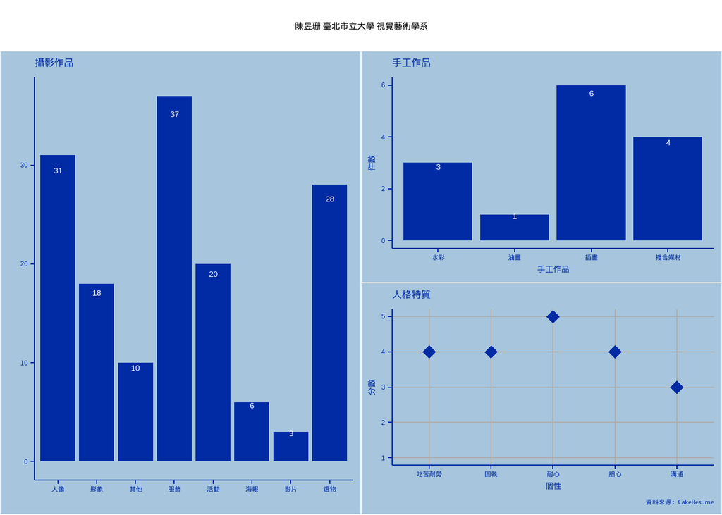

```r
load("graphData.Rda") # 此行為第一行
#choose_palette(gui="shiny")


photograph %>%
  ggplot(aes(x=攝影作品,y = 張數))+
  geom_bar(stat="identity",position = position_dodge(),fill="#002BA4")+
  geom_text(aes(label=張數),position = position_stack(vjust = 0.95),color="white")+
  labs(title = "攝影作品")+
  theme(
    plot.background = element_rect(fill = "#A7C6DD"),
    panel.background = element_rect(fill = "#A7C6DD"),
    axis.title = element_text(hjust = 10,face ="bold",color = "#002BA4"),
    axis.line = element_line(color = "#002BA4"),
    axis.ticks = element_line(color = "#002BA4"),
    axis.text = element_text(color = "#002BA4"),
    plot.title = element_text(color = "#002BA4"),
    plot.caption  = element_text(color = "#002BA4"),
  )->plot.photograph

painting %>%
  ggplot(aes(x=手工作品,y=件數))+
  geom_bar(stat="identity",fill="#002BA4")+
  geom_text(aes(label=件數),position = position_stack(vjust =0.95),color="white")+
  labs(title = "手工作品")+
  theme(
    plot.background = element_rect(fill = "#A7C6DD"),
    panel.background = element_rect(fill = "#A7C6DD"),
    axis.title = element_text(color = "#002BA4"),
    axis.line = element_line(color = "#002BA4"),
    axis.ticks = element_line(color = "#002BA4"),
    axis.text = element_text(color = "#002BA4"),
    plot.title = element_text(color = "#002BA4"),
    plot.caption  = element_text(color = "#002BA4")
  ) ->plot.painting

personality %>%
  ggplot(aes(x = 個性,y = 分數))+
  geom_point(shape = 18,size = 4,color = "#002BA4")+
  scale_y_continuous(limits = c(1,5))+
  labs(title = "人格特質",
       caption = "資料來源：CakeResume")+
  theme(
    plot.background = element_rect(fill = "#A7C6DD"),
    panel.background = element_rect(fill = "#A7C6DD"),
    axis.title = element_text(color = "#002BA4"),
    axis.line = element_line(color = "#002BA4"),
    axis.ticks = element_line(color = "#002BA4"),
    axis.text = element_text(color = "#002BA4"),
    plot.caption  = element_text(color = "#002BA4"),
    panel.grid.major = element_line(color = "#AEAEAE"),
    plot.title = element_text(color = "#002BA4")
  ) ->plot.personality

ggdraw()+
  draw_plot(plot.personality, 0.5, 0, 0.5, 0.45) +
  draw_plot(plot.photograph, 0, 0, 0.5, 0.9) +
  draw_plot(plot.painting, 0.5, 0.45, 0.5, 0.45)
grid.text("陳昱珊 臺北市立大學 視覺藝術學系", x = 0.5, y = 0.95)
```

#### 設計說明

說明想傳達的訊息（必要）及設計想法（非必要）。寫在***下一行。

原先履歷的作者對於攝影及美術方面頗有興趣，也希望可以應徵這方面的工作。

其作者原先也有過一些作品，所以我將作品的數量呈現出來，主要想表達她自身做過的作品，由於關於藝術方面的作品的美感很難用數據表達，所以選擇展現數量。

至於人格特質方面，是我藉由作者的自我介紹以自己的想法用分數表現出來，在表現上可能不甚準確。以1-5為評價，其中1為最低，5為最高。這些都是作者願意寫在履歷表上的人格特質，所以我認為應該都不會太差，因此，在這方面上我最低只給到3分，算是屬於中間值。

最後是作者的就業經驗。作者的就業經驗老實說幾乎和攝影、美術方面不太有關係，我認為這對作者希望應徵的工作可能沒有太大加分，所以我便沒有以圖展示出來。

資料來源：https://www.cakeresume.com/resumes/rosarosa161